# 1_Введение_в_Google_Colab

[figure not shown]

**Навигация по уроку**

## Вступительное слово

## Google Colaboratory

Google Colaboratory - это бесплатная платформа для интерактивных блокнотов Jupyter. В ней можно запускать блокноты как на языке Python, так и R. А самое главное, что все блокноты можно использовать совместно.

Jupyter, а следовательно и Google Colaboratory - это программное обеспечение, которое объединяет в едином редактируемом документе (блокноте):

1. Код (в том числе редактор с подсветкой синтаксиса)
2. Исходные данные
3. Пояснения
4. Результат вычислений (в том числе и сформированную графику)

В отличие от интегрированных сред разработки, нацеленных, прежде всего, на работу с кодом и отчуждаемый от неё результат (отлаженный код и исполняемую программу), интерактивный блокнот предполагает последовательное создание документа, сочетающего код и результаты его выполнения, в этом смысле такой подход сочетается с концепцией грамотного программирования, предполагающей единую среду для программирования и документирования.

В Google Colaboratory все блокноты хранятся на GoogleDrive, о чем свидетельствует логотип слева от названия блокнота:

[figure not shown]

Таким образом Colab - это блокнот Jupyter, который загружен на GoogleDrive. Работа с Google Colab очень схожа с работой в Google Документах или Google Таблицах. Блокнотами также можно делиться с друзьями или коллегами, создавать копии на диске.

### Копирование блокнота

В качестве первого упражнения давайте сделаем копию текущего блокнота. Для этого откройте меню "Файл" (как на скрине ниже) и выберите пункт "Сохранить копию на Диске". Откроется новая вкладка с вашей копией блокнота. Он уже сохранен в вашу папку на диске.

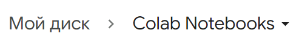

[figure not shown]

### Открытие блокнота

Чтобы открыть ранее сохраненный Colab, откройте меню "Файл" (как на скрине ниже) и выберите пункт "Открыть блокнот". Либо вбейте в адресную строку ссылку: https://colab.research.google.com/. Откроется диалоговое окно, в котором сможете найти свой ранее сохраненный файл.

[figure not shown]

**Постарайтесь запомнить путь к проектам Colab https://colab.research.google.com/**

### Создание нового блокнота

Создать новый блокнот можно двумя разными способами.

**Первый способ.** Открываем в меню "Файл" пункт "Создать блокнот". Создаётся новая вкладка. Кликаем мышкой на имя блокнота. И вводим новое имя, например, "Первый способ". После ввода имени нажимаем кнопку на клавиатуре "Enter", либо на телефоне кнопку "Ввод". Да, именно, вам не показалось. В Colab можно писать программы прямо с телефона.

[figure not shown]

**Второй способ.** Вводим в адресную строку браузера ссылку на Colab (https://colab.research.google.com/). В открывшемся диалоговом окне, нажимаем синюю кнопку "Создать блокнот". Далее как в первом способе переименовываем блокнот. Например, называем "Второй способ". Для завершения ввода попробуйте не нажимать "Enter", а кликну мышью за пределом поля ввода имени. Новое имя также сохраниться.

[figure not shown]

### Ячейки Colab (блокнота)

В блокноте можно создавать ячейки двух видов: **текстовые ячейки** и **ячейки с кодом**.

**Текстовые ячейки** предназначены, как следует из названия, для создания текстовых блоков, вставки видео и изображений. До текущего момента в блокноте использовались только текстовые ячейки. В текстовых ячейках используется специальный синтаксис, который называется **Markdown**. Он широко применяется среди разработчиков для описания своих проектов (документирования) в репозиториях (их также называют Репы). Самая популярная репа среди разработчиков - это **GitHub**.

**GitHub** — веб-сервис, который основан на системе **Git**. Это такая социальная сеть для разработчиков, которая помогает удобно вести коллективную разработку IT-проектов. Здесь можно публиковать и редактировать свой код, комментировать чужие наработки, следить за новостями других пользователей.

**Git** - это распределённая система контроля версий, которую создал Линус Торвальд для управления разработкой ядра Linux. Как вы, наверное, уже догадались, именно он является разработчиком операционной системы Linux. Как он в шутку выражался, что Linux он назвал в честь себя, так же как и git. Git на сленге означает "мерзавец".

Если вы хотите, чтобы ваше резюме выгодно отличалось от других, то выполняя домашние задания, практические проекты, копируйте их в свои репозитории и смело на них ссылайтесь в резюме. Ваша репа - ваш портфолио.

**Ячейки с кодом** - это ячейки, в которых вы пишите свою программу и выполняете код. Только делаете это последовательно, ячейку за ячейкой. Это довольно удобный подход. Если у вас возникла ошибка, то не обязательно выполнять весь код заново, достаточно перезапустить эту ячейку. И все последующие.

Для того чтобы научиться работать с ячейками решим простую задачу.

**Задача. С какой скоростью надо кинуть камень, чтобы он стал спутником Земли?**

Для того чтобы создать текстовую ячейку и вставить в неё описание нажмите на кнопку **"+ Текст"** (**"+ Тт"** - в мобильной версии) в левом верхнем углу блокнота. Чтобы отредактировать созданную ячейку, кликните по ней дважды мышкой и введите описание задачи.

Для того чтобы создать ячейку с кодом нажмите на кнопку **"+ Код"** (**"+ <>"** - в мобильной версии) в левом верхнем углу блокнота. Чтобы отредактировать созданную ячейку, кликните по ней один раз мышкой и введите код. Для запуска выполнения кода в ячейке, выделите ее и нажмите Ctrl+Enter, либо в меню "Среда выполнения" выберите один из пунктов меню: "Выполнить код в сфокусированной ячейке" или "Запустить выбранный код". Так же можно выполнить весь код последовательно в блокноте, выбрав в меню "Среда выполнения" пункт "Выполнить все".

```python
# Это ячейка с кодом
(6.67*10**(-11) * 5.97 * 10**(24) / 6371000)**(1/2)
```

```
7905.8083112450695
```

После выполнения ячейки, результат последней ячейки выводиться в блокнот. Также при установке необходимых библиотек, все предупреждения и информация об установке так же будет выводиться в блокнот. Вы, наверное, заметили, что когда фокусируете мышку на ячейке, то слева от нее появляется значок "треугольник в кружочке", по которому также можно запустить выполнение ячейки с кодом.

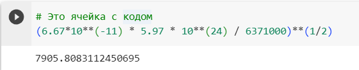

Таким образом мы получили, что если запустить камень со скоростью 7900 м/с, то он станет искусственным спутником земли и будет вращаться вокруг земли бесконечно долго, не падая на нее. Данную задачу мы решили с помощью языка программирования **Python**, о котором подробно пойдет речь в следующих уроках.

С помощью символа **#** в Python вставляют текстовый комментарий к коду, делают дополнительное пояснение, документируют код, при этом комментарий не оказывает влияния на работу программы. Начинающему разработчику важно приучить себя комментировать код. Это очень полезный навык, делающий код понятным, читаемым и его легче поддерживать.

**Поддерживать код** - выражение из лексикона разработчика, означает вносить правки в программное обеспечение, исправлять ошибки (как свои так и чужие), обновлять программу, если обновились библиотеки и модули, которые используются программой. Операционные системы тоже обновляются. Поэтому, если код не поддерживать, то со временем программа устареет и перестанет запускаться.

### Особенности работы с ячейками с кодом

По мере получения навыков в программировании и постепенного освоения материала, вы будете получать всё сложнее и сложнее примеры. Для некоторых примеров надо знать немного больше, поэтому мы будем прибегать к небольшой хитрости. Весь лишний код мы будем скрывать в блок **"Необходимые функции"**. Вам не нужно вникать в этот код, вскоре вы встретитесь ещё раз, но уже с необходимым багажом знаний. Всё что вам нужно - выполнить эту ячейку. Так как в этих ячейках часто устанавливаются библиотеки, то вывод информации, которую разработчики называют *Логи*, может занимать значительное место. Если же блок **Необходимые функции** не выполняется, а под ним *Логи*, в которых часто встречается слово Error, Traceback и предложение *Искать на StackOverflow*, значит произошла ошибка, обратитесь к Куратору за помощью.

**Выполните код ниже, чтобы увидеть, как выглядит ошибка!!!**

```python
5*ошибка
```

```
---------------------------------------------------------------------------
NameError                                 Traceback (most recent call last)
<ipython-input-2-3129ec6bd5e3> in <cell line: 1>()
----> 1 5*ошибка

NameError: name 'ошибка' is not defined
```

### Делимся ноутбуком

Чтобы поделиться блокнотом с другими пользователями для совместной работы или для просмотра, необходимо открыть к нему доступ.

В появившемся диалоговом окне выберите в разделе "Общий доступ" вариант доступа "Все, у кого есть ссылка". Нажмите на кнопку "Копировать ссылку", а после на кнопку "Готово". Настройки доступа сохранены, а у вас в буфере обмена содержится ссылка на блокнот, которой можно поделиться. **Именно таким методом вы будете открывать доступ куратору для проверки вашей домашней работы.**

[figure not shown]

На этом знакомство с Colab завершено.